## **Bilby**

### Blamed on foxes

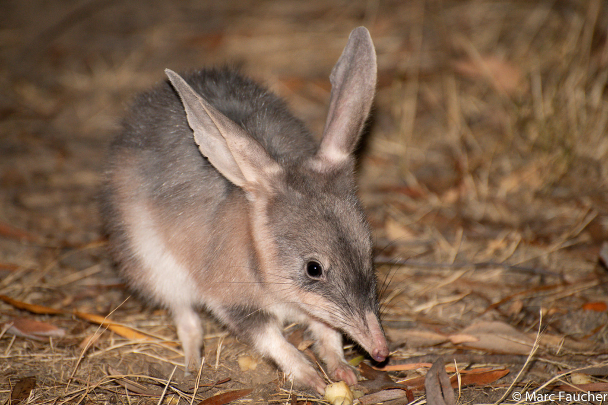

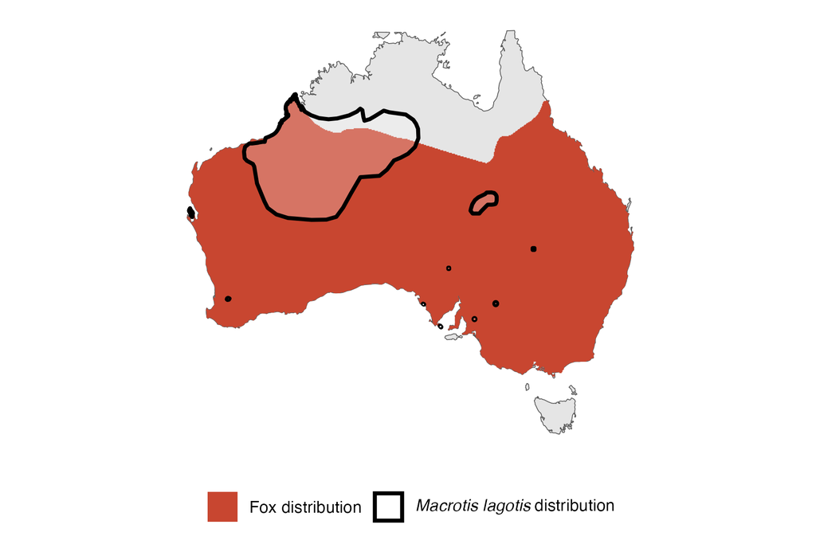

IUCN status: **Vulnerable**

EPBC Predator Threat Rating: **Extreme**

IUCN claim: *“The major threat to the Bilby is predation by introduced red foxes and feral cats”*

### Studies in support

About 70% of bilby extirpation records (36 populations) occurred 1-53 years after foxes arrived and the timing of fox establishment correlates with bilby extirpation across the country (Abbott 2001). Fox probability of occurrence was a negative predictor of bilby occurrence, but model uncertainty was high (Southgate et al. 2007). Paltridge (2005) reported bilby and fox abundance temporal trend data that tended to be weakly negatively correlated, but no statistical analysis was provided. Paltridge (2005) reported that fox signs were found near a dead bilby in Western Australia. Bilbies reintroduced inside fenced reserves (excluding foxes, cats and dingoes) have improved survival rates (Moseby et al. 2011).

### Is the threat claim evidence-based?

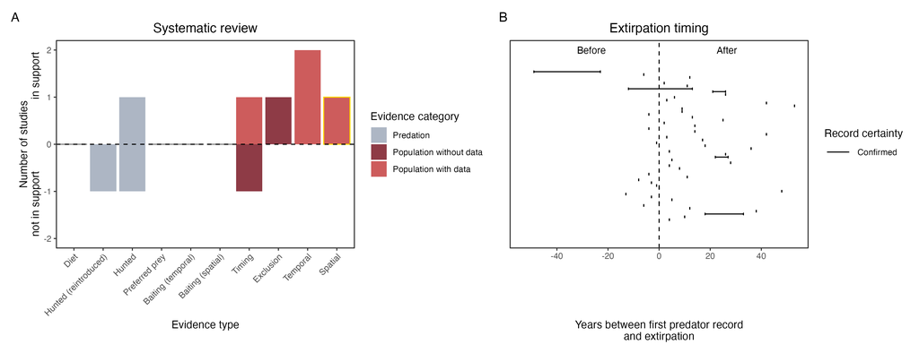

**Evidence linking *Macrotis lagotis* to foxes.** **A.** Systematic review of evidence for an association between *Macrotis lagotis* and foxes. Positive studies are in support of the hypothesis that foxes contribute to the decline of *Macrotis lagotis*, negative studies are not in support. Predation studies include studies documenting hunting or scavenging; baiting studies are associations between poison baiting and threatened mammal abundance where information on predator abundance is not provided; population studies are associations between threatened mammal and predator abundance. Gold borders indicate studies that meet qualities of scientific rigour. **B.** Last records of extirpated populations relative to earliest local records of foxes. Error bars show minimum and maximum extinction intervals. Predator arrival records were digitized from Fairfax 2019. See methods section in Wallach and Lundgren 2025 for details on evidence categories.

### References

Abbott, I., 2001. The Bilby Macrotis lagotis (Marsupialia: Peramelidae) in south-western Australia: original range limits, subsequent decline, and presumed regional extinction. Records Western Australian Museum, 20(3), pp.271-306.

Copley, P., 1999. Natural histories of Australia’s stick-nest rats, genus Leporillus (Rodentia: Muridae). Wildlife Research, 26(4), pp.513-539.

EPBC. (2015) Threat Abatement Plan for Predation by Feral Cats. Environment Protection and Biodiversity Conservation Act 1999, Department of Environment, Government of Australia. (Table A1).

Fairfax, Dispersal of the introduced red fox (Vulpes vulpes) across Australia. Biol. Invasions 21, 1259-1268 (2019).

Geyle, H.M., Schlesinger, C., Banks, S., Dixon, K., Murphy, B.P., Paltridge, R., Doolan, L., Herbert, M. and Dickman, C.R., 2024. Corrigendum to: Unravelling predator–prey interactions in response to planned fire: a case study from the Tanami Desert. Wildlife Research, 51(9), pp.NULL-NULL.

IUCN Red List. https://www.iucnredlist.org/ Accessed June 2023

Lohr, C.A., Dziminski, M., Dunlop, J., Miller, E. and Morris, K., 2021. Reintroduction of bilbies (Macrotis lagotis) to Matuwa, an Indigenous Protected Area in Western Australia. Rangeland Ecology & Management, 78, pp.67-78.

Moseby, K.E., Read, J.L., Paton, D.C., Copley, P., Hill, B.M. and Crisp, H.A., 2011. Predation determines the outcome of 10 reintroduction attempts in arid South Australia. Biological Conservation, 144(12), pp.2863-2872.

Paltridge, R.M., 2005. Predator-prey interactions in the spinifex grasslands of central Australia. PhD Thesis, University of Wollongong

Southgate, R., Paltridge, R., Masters, P. and Carthew, S., 2007. Bilby distribution and fire: a test of alternative models of habitat suitability in the Tanami Desert, Australia. Ecography, 30(6), pp.759-776.

Wallach A.D., Lundgren E.J. (2025) Review of evidence that foxes and cats cause extinctions of Australia’s endemic mammals. BioScience. DOI: 10.1093/biosci/biaf046